# Case Study: Google Data Analytics

Rithika Iyengar

2024-01-02

# Introduction

I recently completed my Google Data Analytics Certificate coursework, and to encapsulate my experience learning data analysis techniques, I decided to complete a case study analyzing the relationship between environment, social and governance (ESG) data, and happiness on both a country-specific and region basis. I will be using RStudio to prepare, process and analyze the correlations between various ESG indicators and happiness rankings on a regional basis. I will be following the ask, prepare, process, analyze, share, act steps of the data analytics process.

# Ask

Hypothetical scenario: The World Bank recently published data on 17 key sustainability themes spanning environmental, social, and governance categories, and want to know how they relate to happiness around the world. Although the World Happiness Report already provides information on GDP per capita, social support, healthy life expectancy, freedom to make life choices, generosity, and perceptions of corruption, the World Bank wishes to further contextualize these categories with their ESG data. The questions that the World Bank would like to be answered to better guide their sustainability themes are:

1. How does income inequality relate to happiness?
2. How do measures of gender parity and happiness relate to each other?
3. How does health relate to happiness?
4. How can we make people happier?

# Prepare

For this analysis, I will be using both the World Bank’s Environment, Social And Governance Dataset which you can find [here](https://datacatalog.worldbank.org/search/dataset/0037651) and the Sustainable Development Solutions Network’s *World Happiness Report* database, which you can find [here](https://www.kaggle.com/datasets/unsdsn/world-happiness). First, I downloaded and previewed the ESG dataset, Happiness dataset, along with packages that I would use in my analysis.

```r
library(readr)
library(tidyverse)
library(sos)
library(reshape2)
library(hrbrthemes)
ESG <- read_csv("C:/Users/rithi/OneDrive/Documents/R/Case Study/ESGData.csv", show_col_types = FALSE)
```

```r
head(ESG)
```

| Country Name | Country Code | Indicator Name | Indicator Code | 1960 | 1961 | 1962 | 1963 | 1964 | 1965 | 1966 | 1967 | 1968 | 1969 | 1970 | 1971 | 1972 | 1973 | 1974 | 1975 | 1976 | 1977 | 1978 | 1979 | 1980 | 1981 | 1982 | 1983 | 1984 | 1985 | … |
| --- | --- | --- | --- | --- | --- | --- | --- | --- | --- | --- | --- | --- | --- | --- | --- | --- | --- | --- | --- | --- | --- | --- | --- | --- | --- | --- | --- | --- | --- | --- |
| Arab World | ARB | Access to clean fuels and technologies for cooking (% of population) | EG.CFT.ACCS.ZS | NA | NA | NA | NA | NA | NA | NA | NA | NA | NA | NA | NA | NA | NA | NA | NA | NA | NA | NA | NA | NA | NA | NA | NA | NA | NA | … |
| Arab World | ARB | Access to electricity (% of population) | EG.ELC.ACCS.ZS | NA | NA | NA | NA | NA | NA | NA | NA | NA | NA | NA | NA | NA | NA | NA | NA | NA | NA | NA | NA | NA | NA | NA | NA | NA | NA | … |
| Arab World | ARB | Adjusted savings: natural resources depletion (% of GNI) | NY.ADJ.DRES.GN.ZS | NA | NA | NA | NA | NA | NA | NA | NA | NA | NA | 5.961207 | 6.0654688 | 8.242519 | 11.302722 | 24.10877186 | 16.6838378 | 18.46105673 | 18.3779663 | 15.8841961 | 33.6436697 | 27.42701307 | 20.16178840 | 11.2858012 | 9.75367784 | 9.67080006 | 8.28927424 | … |
| Arab World | ARB | Adjusted savings: net forest depletion (% of GNI) | NY.ADJ.DFOR.GN.ZS | NA | NA | NA | NA | NA | NA | NA | NA | NA | NA | 0.174568 | 0.1392869 | 0.132084 | 0.152424 | 0.08739017 | 0.0987598 | 0.06634092 | 0.1024111 | 0.1071026 | 0.0742278 | 0.05775997 | 0.05511125 | 0.1141438 | 0.08148861 | 0.07954067 | 0.03830569 | … |
| Arab World | ARB | Agricultural land (% of land area) | AG.LND.AGRI.ZS | NA | 30.98141 | 30.98266 | 31.00705 | 31.018 | 31.04247 | 31.0504 | 31.10322 | 31.13357 | 31.19043 | 31.254493 | 31.3865877 | 31.499948 | 31.496808 | 31.55080689 | 31.5296482 | 31.59973643 | 31.6219972 | 31.6660778 | 31.6784939 | 31.75886761 | 31.45431432 | 31.4803028 | 31.52874746 | 31.94226961 | 32.44217664 | … |
| Arab World | ARB | Agriculture, forestry, and fishing, value added (% of GDP) | NV.AGR.TOTL.ZS | NA | NA | NA | NA | NA | NA | NA | NA | 14.81107 | 14.41270 | 14.725729 | 13.9856621 | 13.866942 | 12.405715 | 7.76859077 | 7.9892460 | 7.43578746 | 7.1015293 | 7.3653083 | 5.7185206 | 4.83765767 | 5.22183193 | 6.1219054 | 6.86358911 | 7.45277426 | 8.22121352 | … |

As we can see, the data is in long format, and includes yearly values for a range of indicators spanning 1960-2023.

# Process and Analyze

After looking at the structure of the ESG dataset on R and the Happiness datasets on Excel, I decided to convert each dataset (if necessary) to wide format, split both datasets up into years, and merge them year by year.

I also decided to focus on a few key variables from the datasets that can act as proxy variables for the questions asked by the World Bank. For the inequality question, there were no direct measures of inequality in the ESG dataset, so I decided to use the GDP per Capita measure in the Happiness dataset to compare against countries’ happiness scores.For the second question, I decided to look at the proportion of women in national parliaments, female to male labor force participation, and gender parity in school enrollment rates as proxies for gender equity to compare against happiness. For the third question, I used life expectancy, mortality rates for children under 5 and undernourishment rates in the ESG dataset.

Next, I created a subset of the ESG dataset containing these relevant variables.

```r
View(ESG)
new1_ESG <- ESG[3268:16970, c(1, 3, 4, 60, 61, 62, 63, 64)] #restricting the dataset to individual countries and years of interest
new2_ESG <- subset(new1_ESG,`Indicator Code`=='SP.DYN.LE00.IN'|`Indicator Code` == 'SH.DYN.MORT' | `Indicator Code` == 'SN.ITK.DEFC.ZS' | `Indicator Code` == 'SG.GEN.PARL.ZS' | `Indicator Code` == 'SL.TLF.CACT.FM.ZS' | `Indicator Code` == 'SE.ENR.PRSC.FM.ZS')#restricting the dataset to indicators of interest
new3_ESG <- new2_ESG[,-c(3)] %>%  #removing code names for indicators
  rename(Country = `Country Name`) %>%
  rename(Indicator = `Indicator Name`)
#Creating separate tables for each year with the same format as the Happiness datasets
ESG_2019 <- new3_ESG[,c(1,2,7)] %>%
  dcast(Country  ~ Indicator,value.var="2019")
ESG_2018 <- new3_ESG[,c(1,2,6)] %>%
  dcast(Country  ~ Indicator,value.var="2018")
ESG_2017 <- new3_ESG[,c(1,2,5)] %>%
  dcast(Country ~ Indicator, value.var = "2017")
ESG_2016 <- new3_ESG[,c(1,2,4)] %>%
  dcast(Country ~ Indicator, value.var = "2016")
ESG_2015 <- new3_ESG[,c(1,2,3)] %>%
  dcast(Country ~ Indicator, value.var = "2015")
```

For reference, the exact indicators that correspond to the codes mentioned above are:

- SP.DYN.LE00.IN = Life expectancy at birth, total (years)
- SH.DYN.MORT = Mortality rate, under-5 (per 1,000 live births)
- SN.ITK.DEFC.ZS = Prevalence of undernourishment (% of population)
- SG.GEN.PARL.ZS = Proportion of seats held by women in national parliaments (%)
- SL.TLF.CACT.FM.ZS = Ratio of female to male labor force participation rate (%) (modeled ILO estimate)
- SE.ENR.PRSC.FM.ZS = School enrollment, primary and secondary (gross), gender parity index (GPI)

I then imported and cleaned the Happiness datasets to clarify titles.

```r
H_2015 <- read_csv("C:/Users/rithi/OneDrive/Documents/R/Case Study/archive (2)/2015.csv") %>%
  rename(H_Rank_2015 = `Happiness Rank`) %>%
  rename(H_Score_2015 = `Happiness Score`) %>%
  rename(Life_Exp_2015 = `Health (Life Expectancy)`) %>%
  rename(GDP_Cap_2015 = `Economy (GDP per Capita)`) %>%
  arrange(Country) %>%
  select(Country, Region, H_Rank_2015, H_Score_2015, Life_Exp_2015, GDP_Cap_2015)%>%
  mutate(across(where(is.character), str_trim), show_col_types = FALSE)
H_2019 <- read_csv("C:/Users/rithi/OneDrive/Documents/R/Case Study/archive (2)/2019.csv") %>%
  rename(Country = `Country or region`) %>%
  rename(H_Rank_2019 = `Overall rank`) %>%
  rename(H_Score_2019 = "Score") %>%
  rename(Life_Exp_2019 = `Healthy life expectancy`) %>%
  rename(GDP_Cap_2019 = `GDP per capita`) %>%
  arrange(Country) %>%
  select(Country, H_Rank_2019, H_Score_2019, Life_Exp_2019, GDP_Cap_2019) %>%
  mutate(across(where(is.character), str_trim), show_col_types = FALSE)
H_2018 <- read_csv("C:/Users/rithi/OneDrive/Documents/R/Case Study/archive (2)/2018.csv") %>%
  rename("Country" = `Country or region`) %>%
  rename(H_Rank_2018 = `Overall rank`) %>%
  rename(H_Score_2018 = "Score") %>%
  rename(Life_Exp_2018 = `Healthy life expectancy`) %>%
  rename(GDP_Cap_2018 = `GDP per capita`) %>%
  arrange(Country) %>%
  select(Country, H_Rank_2018, H_Score_2018, Life_Exp_2018, GDP_Cap_2018) %>%
  mutate(across(where(is.character), str_trim), show_col_types = FALSE)
H_2017 <- read_csv("C:/Users/rithi/OneDrive/Documents/R/Case Study/archive (2)/2017.csv") %>%
  rename(H_Rank_2017 = "Happiness.Rank") %>%
  rename(H_Score_2017 = "Happiness.Score") %>%
  rename(Life_Exp_2017 = "Health..Life.Expectancy.") %>%
  rename(GDP_Cap_2017 = "Economy..GDP.per.Capita.") %>%
  arrange(Country) %>%
  select(Country, H_Rank_2017, H_Score_2017, Life_Exp_2017, GDP_Cap_2017) %>%
  mutate(across(where(is.character), str_trim), show_col_types = FALSE)
H_2016 <- read_csv("C:/Users/rithi/OneDrive/Documents/R/Case Study/archive (2)/2016.csv") %>%
  rename(H_Rank_2016 = `Happiness Rank`) %>%
  rename(H_Score_2016 = `Happiness Score`) %>%
  rename(Life_Exp_2016 = `Health (Life Expectancy)`) %>%
  rename(GDP_Cap_2016 = `Economy (GDP per Capita)`) %>%
  arrange(Country) %>%
  select(Country, Region, H_Rank_2016, H_Score_2016, Life_Exp_2016,
         GDP_Cap_2016) %>%
  mutate(across(where(is.character), str_trim), show_col_types = FALSE)
```

I then combined the Happiness datasets and ESG datasets by year using the “merge” function.

```r
F_2015 <- merge(H_2015,ESG_2015, by="Country")
F_2016 <- merge(H_2016, ESG_2016, by="Country")
F_2017 <- merge(H_2017, ESG_2017, by="Country")
F_2018 <- merge(H_2018, ESG_2018, by="Country")
F_2019 <- merge(H_2019, ESG_2019, by="Country")
```

# Analyze (Cont.) and Share

As a reminder, these are the questions the World Bank gave as their business task:

1. How does income inequality relate to happiness?
2. How do measures of gender parity and happiness relate to each other?
3. How does health relate to happiness?
4. How can we make people happier?

## Question 1

To tackle the first question, let’s begin by looking at the relationship between income inequality and happiness through capturing the correlation between GDP per Capita and Happiness in 2019.

```r
require(devtools)
install_version("ggplot2", version = "2.2.1", repos = "http://cran.us.r-project.org")
```

[output not shown]

```r
library(ggplot2)
library(hrbrthemes) #calling relevant packages
```

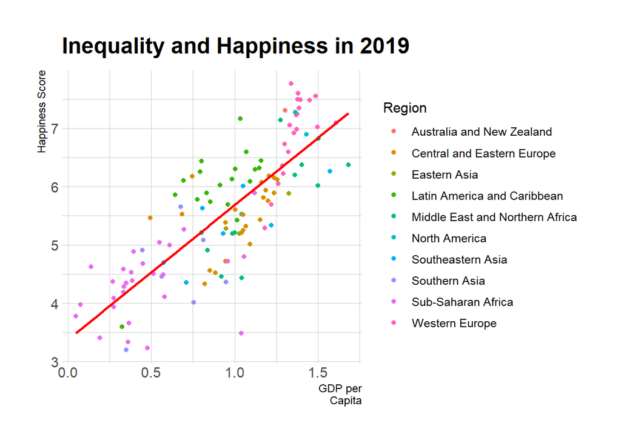

```r
ggplot(data = Final, aes(x = GDP_Cap_2019, y = H_Score_2019,))+
  labs(title = "Inequality and Happiness in 2019", x = "GDP per
       Capita", y = "Happiness Score", colour = "Region") + geom_point(aes(colour = Region.y), show.legend = TRUE) +
   geom_smooth(method=lm , color="red", se=FALSE) +
  theme_ipsum()
```

As seen by the scatter plot, there is a strong positive relationship between GDP per Capita and Happiness. Sub-Sarahan African countries seem to have the lowest of both GDP per Capita and Happiness, while Australia and New Zealand have both a high GDP per Capita and Happiness Score. Does this result remain consistent for the years 2015-2018?

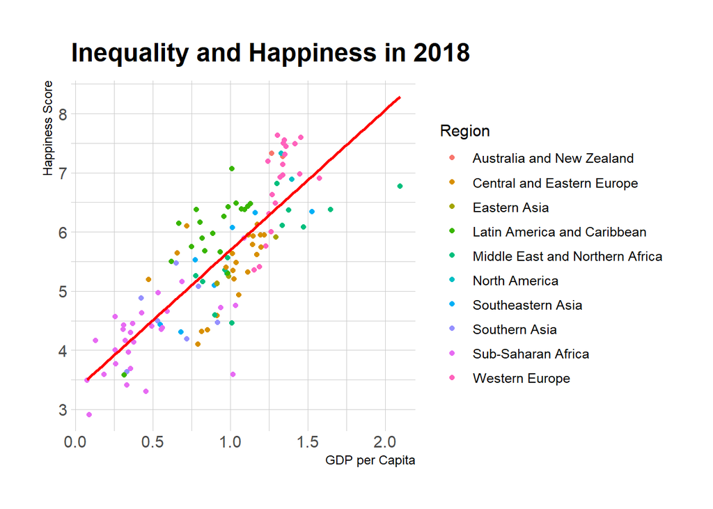

```r
#2018
ggplot(Final, aes(GDP_Cap_2018, H_Score_2018,))+
  labs(title = "Inequality and Happiness in 2018", x = "GDP per Capita", y = "Happiness Score", colour = "Region") +
  geom_point(aes(colour = Final$Region.y), show.legend = TRUE) + geom_smooth(method=lm , color="red", se=FALSE) +
  theme_ipsum()
```

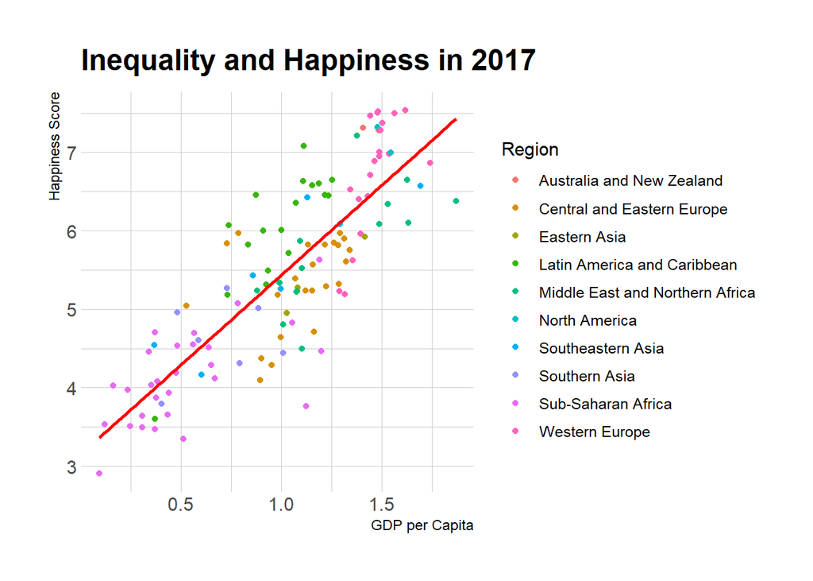

```r
#2017
ggplot(Final, aes(GDP_Cap_2017, H_Score_2017,))+
  labs(title = "Inequality and Happiness in 2017", x = "GDP per Capita", y = "Happiness Score", colour = "Region") +
  geom_point(aes(colour = Final$Region.y), show.legend = TRUE) + geom_smooth(method=lm , color="red", se=FALSE) +
  theme_ipsum()
```

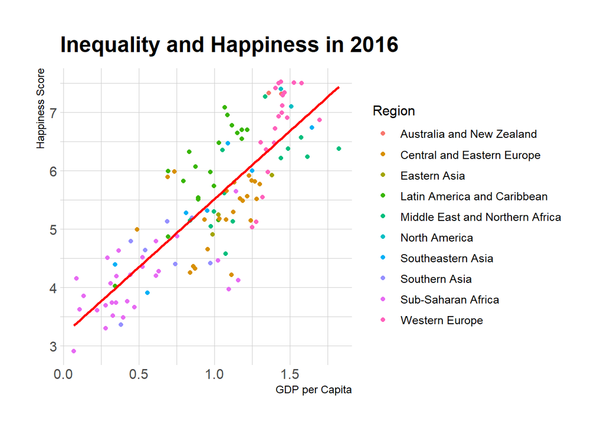

```r
#2016
ggplot(Final, aes(GDP_Cap_2016, H_Score_2016,))+
  labs(title = "Inequality and Happiness in 2016", x = "GDP per Capita", y = "Happiness Score", colour = "Region") +
  geom_point(aes(colour = Final$Region.y), show.legend = TRUE) + geom_smooth(method=lm , color="red", se=FALSE) +
  theme_ipsum()
```

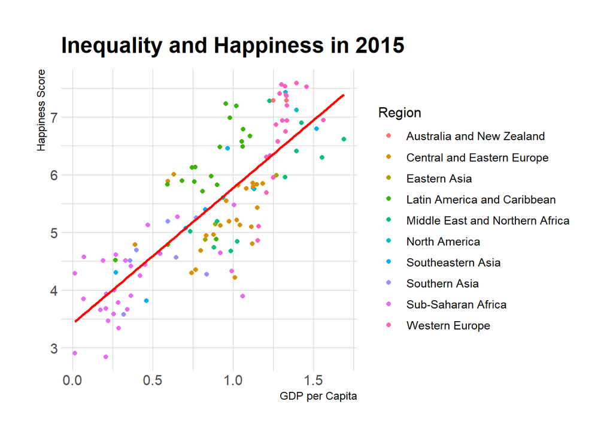

```r
#2015
ggplot(Final, aes(GDP_Cap_2015, H_Score_2015,))+
  labs(title = "Inequality and Happiness in 2015", x = "GDP per Capita", y = "Happiness Score", colour = "Region") +
  geom_point(aes(colour = Final$Region.y), show.legend = TRUE) + geom_smooth(method=lm , color="red", se=FALSE) +
  theme_ipsum()
```

As we can see, the trend generally stays the same, with minor variations. However, countries in the middle of the plane have more variation than the Sub-Saharan African countries near the origin and Austalia/New Zealand.

## Question 2

```r
install.packages("GGally", repos = "http://cran.us.r-project.org")
library(GGally)
```

Then, I create a dataset to look at Gender and Happiness specifically, in 2015. I shortened variables to improve clarity.

```r
Gender_2015 <- Final %>%
  rename(Female_Male_LFPR="Ratio of female to male labor force participation rate (%) (modeled ILO estimate).x") %>%
  rename(Gender_Parity_Schools = "School enrollment, primary and secondary (gross), gender parity index (GPI).x") %>%
  rename(Women_in_Govt = "Proportion of seats held by women in national parliaments (%).x") %>%
  select(H_Score_2015, Female_Male_LFPR, Gender_Parity_Schools, Women_in_Govt)
```

We can visualize the correlation between these variables in 2015 using ggcorr.

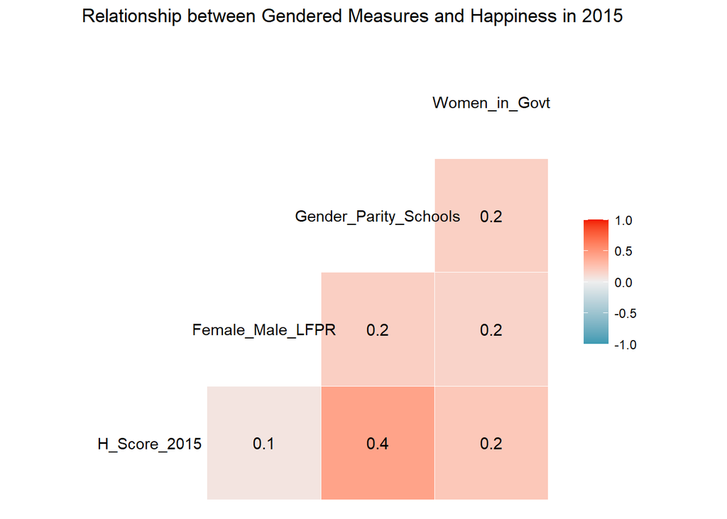

```r
ggcorr(Gender_2015, label=TRUE) + labs(title = "Relationship between Gendered Measures and Happiness in 2015")
```

The gendered measures correlate with each other positively, but not significantly. There does seem to be a positive relationship between happiness and gender parity in schools, but this relationship is not very strong. Are there stronger correlations between these variables in 2016, 2017, or 2018?

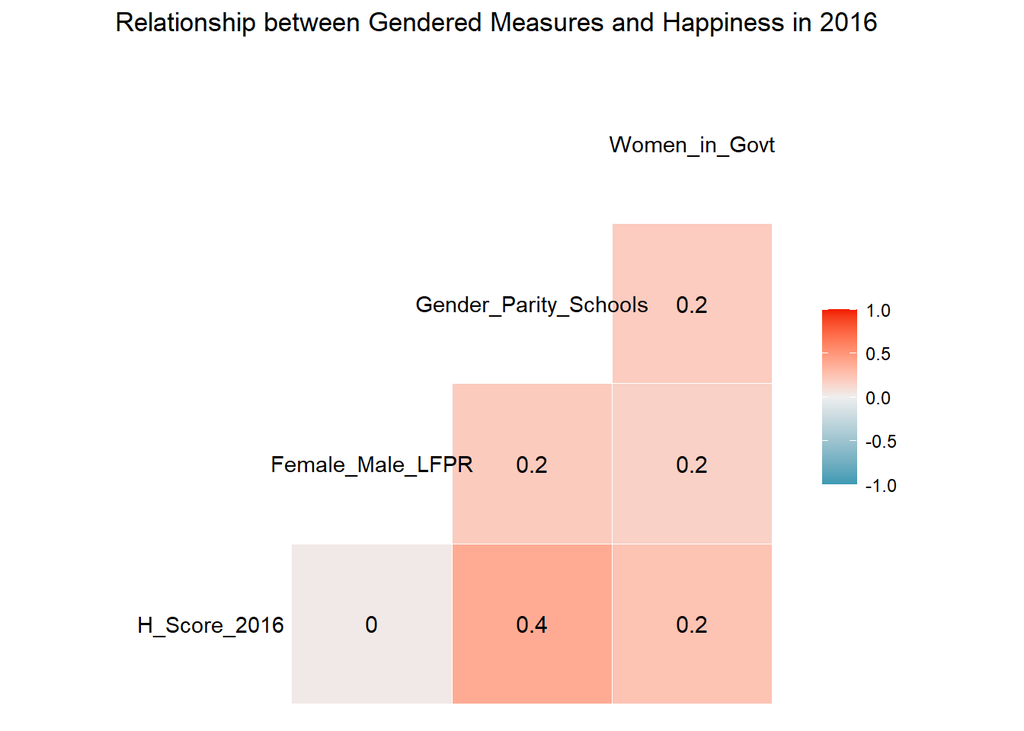

```r
#2016
view(Final)
Gender_2016 <- Final %>%
  rename(Female_Male_LFPR = "Ratio of female to male labor force participation rate (%) (modeled ILO estimate).y") %>%
  rename(Gender_Parity_Schools = "School enrollment, primary and secondary (gross), gender parity index (GPI).y") %>%
  rename(Women_in_Govt = "Proportion of seats held by women in national parliaments (%).y") %>%
  select(H_Score_2016, Female_Male_LFPR, Gender_Parity_Schools,
         Women_in_Govt)
ggcorr(Gender_2016, label=TRUE) + labs(title = "Relationship between Gendered Measures and Happiness in 2016")
```

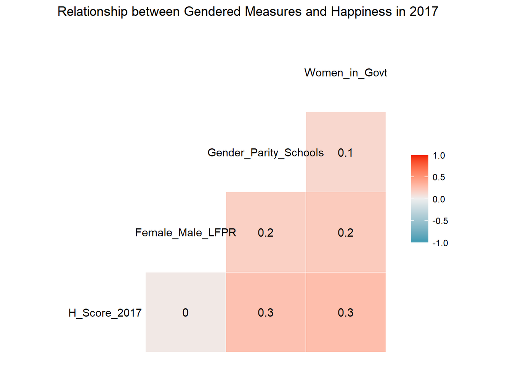

```r
#2017
Gender_2017 <- Final %>%
  rename(Female_Male_LFPR = "Ratio of female to male labor force participation rate (%) (modeled ILO estimate).x.x") %>%
  rename(Gender_Parity_Schools = "School enrollment, primary and secondary (gross), gender parity index (GPI).x.x") %>%
  rename(Women_in_Govt = "Proportion of seats held by women in national parliaments (%).x.x") %>%
  select(H_Score_2017, Female_Male_LFPR, Gender_Parity_Schools,
         Women_in_Govt)
ggcorr(Gender_2017, label=TRUE) + labs(title = "Relationship between Gendered Measures and Happiness in 2017")
```

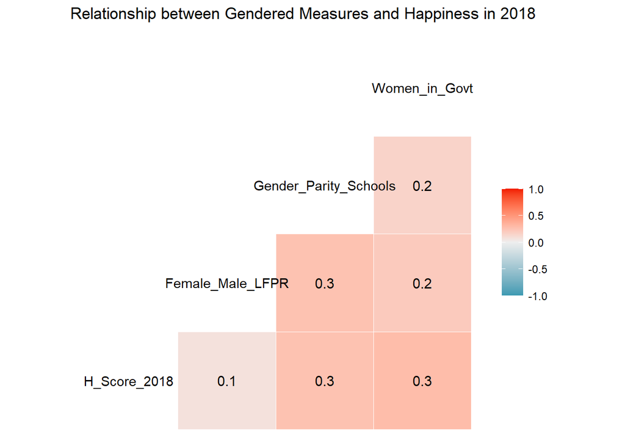

```r
#2018
Gender_2018 <- Final %>%
  rename(Female_Male_LFPR = "Ratio of female to male labor force participation rate (%) (modeled ILO estimate).y.y") %>%
  rename(Gender_Parity_Schools = "School enrollment, primary and secondary (gross), gender parity index (GPI).y.y") %>%
  rename(Women_in_Govt = "Proportion of seats held by women in national parliaments (%).y.y") %>%
  select(H_Score_2018, Female_Male_LFPR, Gender_Parity_Schools,
         Women_in_Govt)
ggcorr(Gender_2018, label=TRUE) + labs(title = "Relationship between Gendered Measures and Happiness in 2018")
```

As seen by these correlation plots, the weak relationships between gender parity variables and happiness persist aross all the years we have looked at. However, gender parity could influence happiness through indirect avenues, and should be further explored. Additionally, we can break up countries by geographic regions, and see if correlations differ between variables. This is likely to be the case because of varied cultural institutions between regions and their different stages of development.

## Question 3

Finally, let’s look at the relationship between health and happiness, starting with 2015. I first create a dataset with the variables specific to health and happiness for 2015.

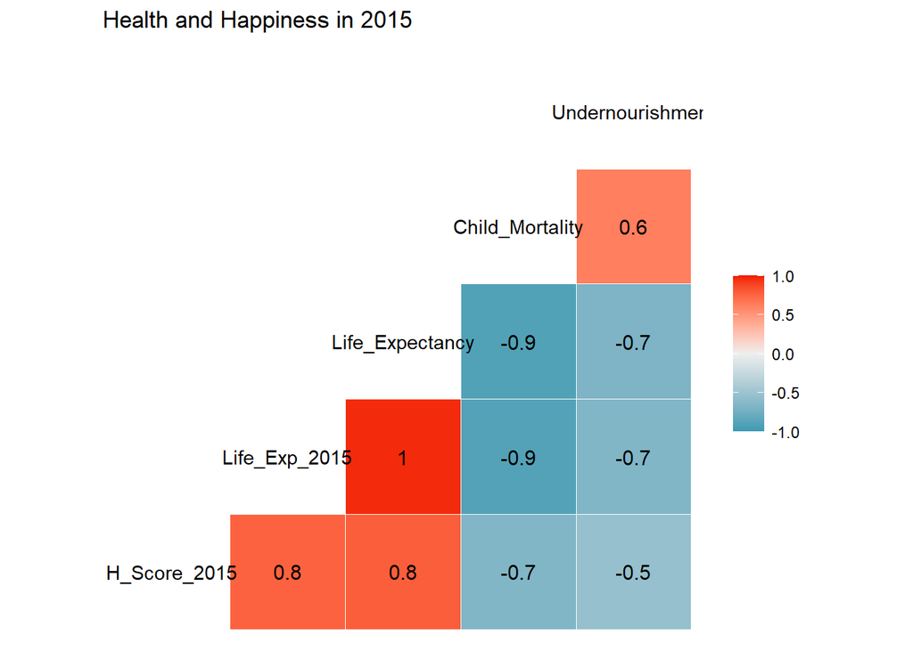

```r
Health_2015 <- Final %>%
  rename(Life_Expectancy = "Life expectancy at birth, total (years).x") %>%
  rename(Child_Mortality = "Mortality rate, under-5 (per 1,000 live births).x")%>%
  rename(Undernourishment = "Prevalence of undernourishment (% of population).x")%>%
  select(H_Score_2015, Life_Exp_2015, Life_Expectancy,
         Child_Mortality, Undernourishment)
ggcorr(Health_2015, label=TRUE) + labs(title = "Health and Happiness in 2015")
```

There are much stronger correlations overall here. As a sanity check, the life expectancy measure used in the World Happiness dataset and the World Bank dataset should match, and they do. Let’s explore some of these relationships more in detail:

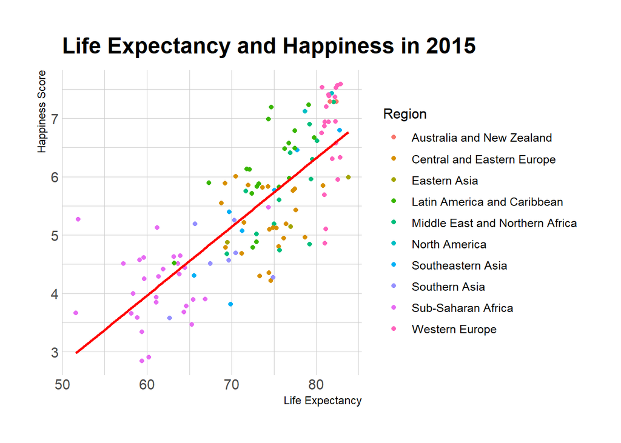

```r
#1) life expectancy and happiness
ggplot(Health_2015, aes(Life_Expectancy, H_Score_2015))+
  labs(title = "Life Expectancy and Happiness in 2015", x = "Life Expectancy", y = "Happiness Score", colour = "Region") +
  geom_point(aes(colour = Final$Region.y), show.legend = TRUE) + geom_smooth(method=lm , color="red", se=FALSE) +
  theme_ipsum()
```

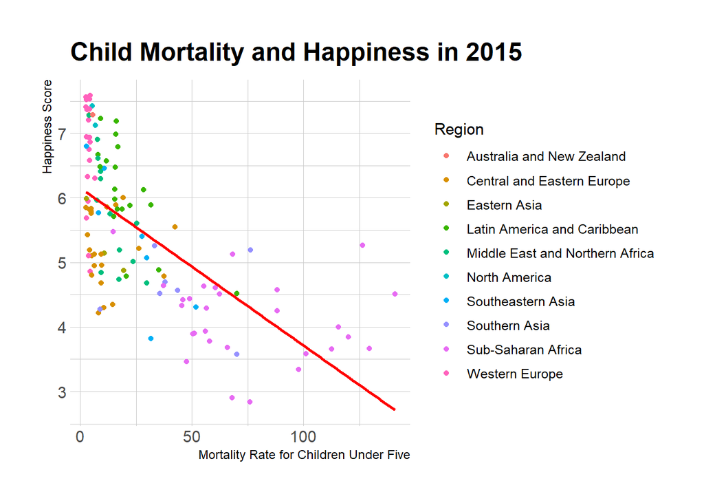

```r
#2) happiness and child mortality --> are parents not as happy when there is child mortality, or does this suggest undernourishment in the general population, which impacts happiness?
ggplot(Health_2015, aes(Child_Mortality, H_Score_2015,))+
  labs(title = "Child Mortality and Happiness in 2015", x = "Mortality Rate for Children Under Five", y = "Happiness Score", colour = "Region") +
  geom_point(aes(colour = Final$Region.y), show.legend = TRUE) + geom_smooth(method=lm , color="red", se=FALSE) +
  theme_ipsum()
```

Now let’s revisit our first correlation plot. Are these correlations consistent across years?

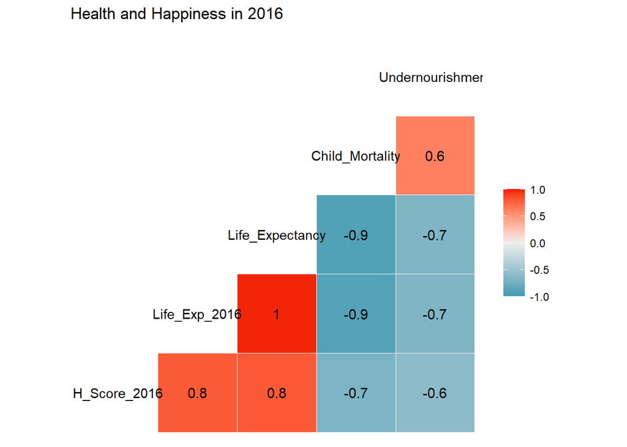

```r
#2016
Health_2016 <- Final %>%
    rename(Life_Expectancy = "Life expectancy at birth, total (years).y") %>%
  rename(Child_Mortality = "Mortality rate, under-5 (per 1,000 live births).y")%>%
  rename(Undernourishment = "Prevalence of undernourishment (% of population).y")%>%
  select(H_Score_2016, Life_Exp_2016, Life_Expectancy, Child_Mortality, Undernourishment)
ggcorr(Health_2016, label=TRUE) + labs(title = "Health and Happiness in 2016")
```

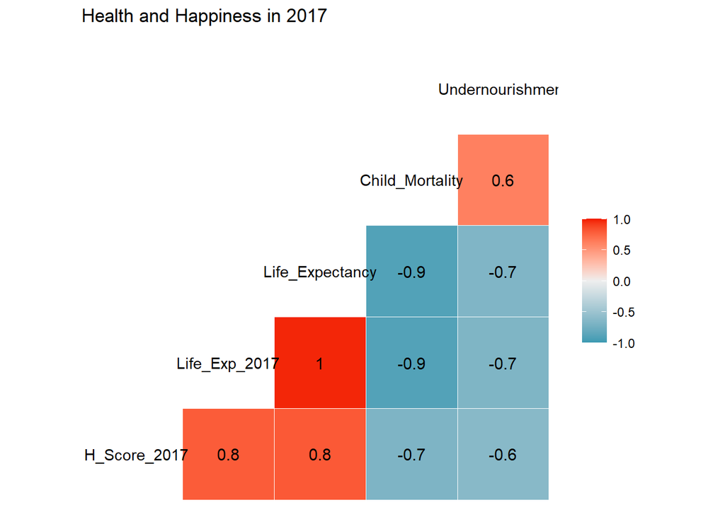

```r
#2017
Health_2017 <- Final %>%
    rename(Life_Expectancy = "Life expectancy at birth, total (years).x.x") %>%
  rename(Child_Mortality = "Mortality rate, under-5 (per 1,000 live births).x.x")%>%
  rename(Undernourishment = "Prevalence of undernourishment (% of population).x.x")%>%
  select(H_Score_2017, Life_Exp_2017, Life_Expectancy, Child_Mortality, Undernourishment)
ggcorr(Health_2017, label=TRUE) + labs(title = "Health and Happiness in 2017")
```

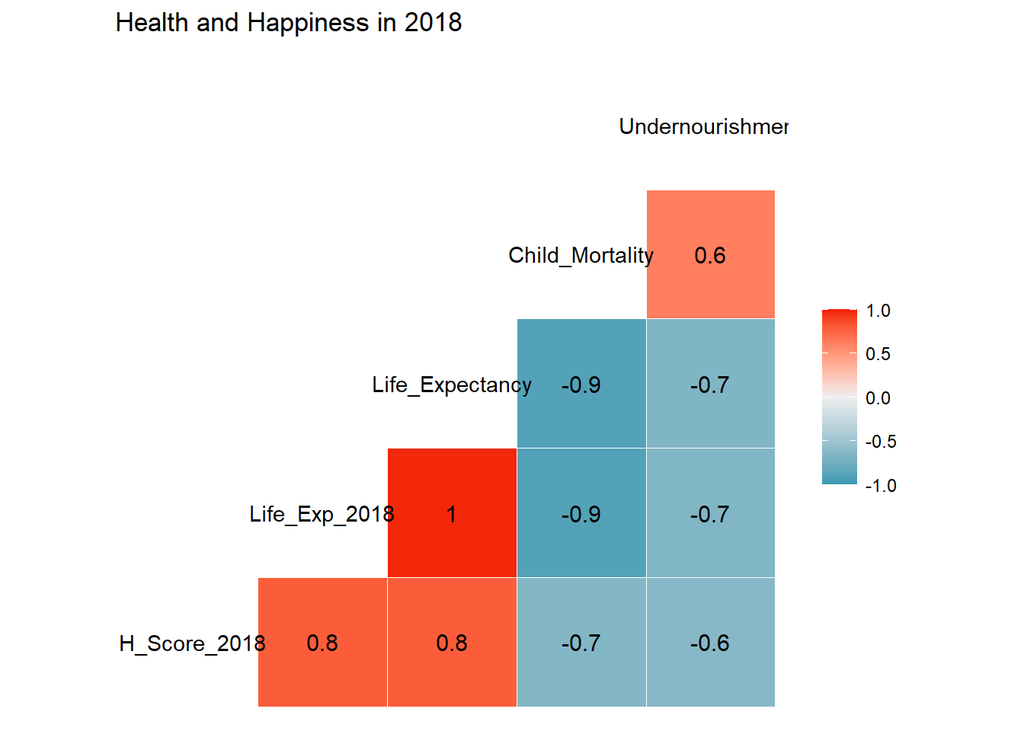

```r
#2018
Health_2018 <- Final %>%
   rename(Life_Expectancy = "Life expectancy at birth, total (years).y.y") %>%
  rename(Child_Mortality = "Mortality rate, under-5 (per 1,000 live births).y.y")%>%
  rename(Undernourishment = "Prevalence of undernourishment (% of population).y.y")%>%
  select(H_Score_2018, Life_Exp_2018, Life_Expectancy, Child_Mortality, Undernourishment)
ggcorr(Health_2018, label=TRUE) + labs(title = "Health and Happiness in 2018")
```

[figure not shown]

```r
#2019
Health_2019 <- Final %>%
    rename(Life_Expectancy = "Life expectancy at birth, total (years)") %>%
  rename(Child_Mortality = "Mortality rate, under-5 (per 1,000 live births)")%>%
  rename(Undernourishment = "Prevalence of undernourishment (% of population)")%>%
  select(H_Score_2019, Life_Exp_2019, Life_Expectancy, Child_Mortality, Undernourishment)
ggcorr(Health_2015, label=TRUE) + labs(title = "Health and Happiness in 2019")
```

# Act

The *World Happiness Report* was designed to advocate for happiness and well-being as a tenet for social policy. This analysis reveals greater insight in the relationship between happiness and three factors:

1. income inequality
2. gender parity, and
3. health.

Through using the World Bank’s ESG data to contextualize and further explore how societies can be happier, we have a deeper insight on policies that can effectively increase happiness across the world. This concludes my case study. I hope you learned something new and saw some cool visualizations!